# AgataPaldyna_H6

## IML - Homework 6

## Dataset: Medical Expenditure Panel Survey

## Methods: **PDP, ALE**

## 1) Key results and comments

Problem polega na predycji wydatków na opiekę zdrowotną osób fizycznych. Zbiór danych zawiera dane pochodzące z sondaży. Zmienne opisują status demograficzny i społeczno-ekonomiczny ankietowanych osób, jak również diagnozy chorób, ograniczenia zdrowotne oraz zgłoszony przez nich stan zdrowia.  
Zbudowany model to **Gradient Boosting Regressor**, zaimplementowany w pakiecie scikit-learn. Zmienne kategoryczne (tj. zmienne, które mają co najwyżej 10 unikalnych wartości - nie dotyczy zmiennych "POVCAT15", "RTHLTH31", "MNHLTH31", które mogą być traktowane jak ciągłe) zostały przekształcone za pomocą kodowania one-hot, natomiast zmienne liczbowe zostały przeskalowane za pomocą StandardScalera. Zmienna celu została przekształcona za pomocą logarytmu o podstawie 3.

### ad 2)

Dla zbudowanego modelu obliczone zostały profile Partial Dependence oraz Accumulated Local Dependence dla zmiennych AGE31X, POVCAT15, RTHLTH31, MNHLTH31 (zmienne liczbowe) oraz GENDER, INSCOV15, CANCERDX, HIBPDX (zmienne kategoryczne). Poniżej znajdują się wykresy tych profili.

[figure not shown]

Jak widać, dla powyższych zmiennych profile PDP i ALE zachowują się podobnie.  
Poniżej bardziej szczegółowe komentarze.

- Zmienna **AGE31X** opisuje wiek pacjenta. Profile PDP i ALE mają tendencję wzrostową, linie nie są gładkie. Można zauważyć nagły spadek w pierwszych kilku latach, a gwałtowne skoki wydatków na opiekę zdrowotną około 20, 40, 50 oraz 75 roku życia. To wszystko wydaje się być dość intuicyjne - dzieci na początku swojego życia przechodzą wiele badań, niektóre mogą się rodzić z jakimiś chorobami (stąd nagły spadek na początku), z wiekiem stan zdrowia się pogarsza, a co za tym idzie wydatki mogą wzrastać (tendencja wzrostowa), w pewnym wieku ludzie zaczynają bardziej dbać o swoje zdrowie, częściej się badać, co za tym idzie może zostać zdiagnozowana jakaś choroba, o której wcześniej nie mieli pojęcia (stąd te skoki wydatków).
- Zmienna **POVCAT15** opisuje poziom ubóstwa rodziny danego pacjenta - im wyższa wartość, tym bogatsza rodzina. Tutaj profile są gładkimi liniami i mają trend wzrostowy. W tym przypadku również wygląda to dość intuicyjnie - im człowiek jest bogatszy, tym więcej wydaje na opiekę zdrowotną.
- Zmienne **MNHLTH31** i **RTHLTH31** opisują samoocenę zdrowia psychicznego i fizycznego, przyjmują wartości od -1 (nie dotyczy) do 5 (zły, słaby). Im wyższa wartość, tym samoocena gorsza. Jak widać powyżej, wartość pierwszej z nich nie wpływa na wydatki, są one praktycznie niezmienne dla różnych jej wartości. Natomiast w przypadku drugiej zmiennej profile PDP i ALE przypominają sigmoidę. Dla małych wartości, czyli dla bardzo dobrej samooceny zdrowia, wydatki są najmniejsze, następnie im gorsza samoocena zdrowia, tym wydatki są coraz większe. Najwięszy wzrost wydatków zauważalny jest między 2 a 3 (samoocena zdrowia: bardzo dobre/dobre).
- Zmienna **CANCERDX** mówi o tym, czy kiedykolwiek został zdiagnozowany rak u danego pacjenta. Przyjmuje wartości -1 (nie dotyczy), 1 (tak), 2 (nie). Jak można się było spodziewać, wydatki na opiekę medyczną są wyższe dla osób, u których kiedykolwiek został zdiagnozowany rak.
- Zmienna **HIBPDX** mówi o tym, czy kiedykolwiek zdiagnozowano u pacjenta wysokie ciśnienie krwi. Podobnie jak w przypadku wcześniej wspomnianej zmiennej, przyjmuje ona wartości -1 (nie dotyczy), 1 (tak), 2 (nie), a wydatki na opiekę medyczną są wyższe dla osób, u których kiedykolwiek zdiagnozowano wysokie ciśnienie krwi.
- Zmienna **GENDER** opisuje płeć pacjenta. Wartość 0 oznacza mężczyznę, a 1 kobietę. Jak widać na wykresie, dla kobiet wydatki na opiekę zdrowotną są średnio ponad półtora raza większe (3^0.5) niż dla mężczyzn.
- Zmienna **INSCOV15** oznacza wskaźnik zakresu ubezpieczenia zdrowotnego w 2015 roku i przyjmuje wartości 1, 2, 3, które oznaczają odpowiednio dowolne prywatne, tylko publiczne, nieubezpieczony. Jak można się było spodziewać, wydatki są najmniejsze u osób nieubezpieczonych. Natomiast zaskakująco niewielka różnica jest między wydatkami osób mających ubezpieczenie prywatne a osób mających ubezpieczenie publiczne.

### ad 3)

[figure not shown]

## 2) Appendix

### Import packages

```python
import dalex as dx
import pandas as pd
import numpy as np
import matplotlib.pyplot as plt

from sklearn.model_selection import train_test_split
from sklearn.ensemble import GradientBoostingRegressor
from sklearn.preprocessing import OneHotEncoder, StandardScaler
from sklearn.linear_model import LinearRegression
from sklearn.pipeline import Pipeline
from sklearn.compose import ColumnTransformer
from sklearn.metrics import r2_score, mean_squared_error, mean_absolute_error
```

### Functions

```python
def transform_target_log3(data, target_name):
    val = data[target_name].values
    return np.array([0 if v == 0 else np.log(v) / np.log(3) for v in val])


def get_categorical_features(data, not_cat_cols_list):
    num_unique = data.nunique()
    categorical_features = num_unique[num_unique <= 10].index.tolist()
    # Remove variables from categorical features list that can be treated as continuous
    for col in not_cat_cols_list:
        categorical_features.remove(col)
    return categorical_features


def print_model_results(y_train, y_pred_train, y_test, y_pred_test):
    mse_train = mean_squared_error(y_train, y_pred_train)
    rmse_train = np.sqrt(mse_train)

    mse_test = mean_squared_error(y_test, y_pred_test)
    rmse_test = np.sqrt(mse_test)

    print("Training: \nRMSE: ", rmse_train, " | MAE: ", mean_absolute_error(y_train, y_pred_train), " | R^2: ", r2_score(y_train, y_pred_train), "\n")
    print("Test: \nRMSE: ", rmse_test, " | MAE: ", mean_absolute_error(y_test, y_pred_test), " | R^2: ", r2_score(y_test, y_pred_test), "\n")


def plot_pdp_ale(exp, cols_type, cols):
    pdp = exp.model_profile(type = "partial", variable_type = cols_type, variables = cols)
    pdp.result["_label_"] = "pdp"
    ale = exp.model_profile(type = "accumulated", variable_type = cols_type, variables = cols)
    ale.result["_label_"] = "ale"
    pdp.plot(ale)
```

### Read and explore data

```python
data = pd.read_csv("./../dane/MEPS_data_preprocessed.csv")
data.drop(columns = ["PANEL", "PERSONWT"], inplace = True) # this variables not meant to be predictive
```

```python
data.head()
```

|  | REGION | AGE31X | GENDER | RACE3 | MARRY31X | EDRECODE | FTSTU31X | ACTDTY31 | HONRDC31 | RTHLTH31 | ... | ADSMOK42 | PCS42 | MCS42 | K6SUM42 | PHQ242 | EMPST31 | POVCAT15 | INSCOV15 | INCOME_M | HEALTHEXP |
| --- | --- | --- | --- | --- | --- | --- | --- | --- | --- | --- | --- | --- | --- | --- | --- | --- | --- | --- | --- | --- | --- |
| 0 | 2 | 52 | 0.0 | 0.0 | 5 | 13 | -1 | 2 | 2 | 4 | ... | 2 | 25.93 | 58.47 | 3 | 0 | 4 | 1 | 2 | 11390.0 | 46612 |
| 1 | 2 | 55 | 1.0 | 0.0 | 3 | 14 | -1 | 2 | 2 | 4 | ... | 2 | 20.42 | 26.57 | 17 | 6 | 4 | 3 | 2 | 11390.0 | 9207 |
| 2 | 2 | 22 | 1.0 | 0.0 | 5 | 13 | 3 | 2 | 2 | 1 | ... | 2 | 53.12 | 50.33 | 7 | 0 | 1 | 2 | 2 | 18000.0 | 808 |
| 3 | 2 | 2 | 0.0 | 0.0 | 6 | -1 | -1 | 3 | 3 | 1 | ... | -1 | -1.00 | -1.00 | -1 | -1 | -1 | 2 | 2 | 385.0 | 2721 |
| 4 | 3 | 25 | 1.0 | 0.0 | 1 | 14 | -1 | 2 | 2 | 1 | ... | 2 | 59.89 | 45.91 | 9 | 2 | 1 | 3 | 1 | 3700.0 | 1573 |

5 rows × 44 columns

```python
data.shape
```

```
(18350, 44)
```

```python
# Check columns types and if there are any missing values
data.info()
```

```
<class 'pandas.core.frame.DataFrame'>
RangeIndex: 18350 entries, 0 to 18349
Data columns (total 44 columns):
 #   Column     Non-Null Count  Dtype
---  ------     --------------  -----
 0   REGION     18350 non-null  int64
 1   AGE31X     18350 non-null  int64
 2   GENDER     18350 non-null  float64
 3   RACE3      18350 non-null  float64
 4   MARRY31X   18350 non-null  int64
 5   EDRECODE   18350 non-null  int64
 6   FTSTU31X   18350 non-null  int64
 7   ACTDTY31   18350 non-null  int64
 8   HONRDC31   18350 non-null  int64
 9   RTHLTH31   18350 non-null  int64
```

[output cut: 36 more lines]

```python
# Check number of unique values in columns
num_unique = data.nunique()
num_unique
```

```
REGION          4
AGE31X         86
GENDER          2
RACE3           2
MARRY31X       10
EDRECODE        7
FTSTU31X        4
ACTDTY31        4
HONRDC31        4
RTHLTH31        6
MNHLTH31        6
HIBPDX          3
CHDDX           3
ANGIDX          3
MIDX            3
OHRTDX          3
STRKDX          3
EMPHDX          3
CHBRON31        3
CHOLDX          3
CANCERDX        3
DIABDX          3
JTPAIN31        3
ARTHDX          3
ARTHTYPE        4
ASTHDX          3
ADHDADDX        3
PREGNT31        3
WLKLIM31        3
ACTLIM31        3
SOCLIM31        3
COGLIM31        3
DFHEAR42        3
DFSEE42         3
ADSMOK42        3
PCS42        3208
MCS42        3177
K6SUM42        27
PHQ242          8
EMPST31         5
POVCAT15        5
INSCOV15        3
INCOME_M     6553
HEALTHEXP    7424
dtype: int64
```

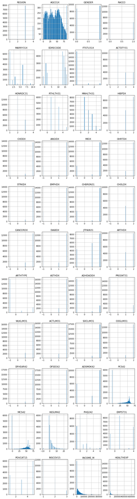

```python
# Check histograms of all variables

fig, axes = plt.subplots(11, 4, figsize = (12, 48))

i = 0
for triaxis in axes:
    for axis in triaxis:
        data.hist(column = data.columns[i], bins = 100, ax = axis)
        i += 1

plt.show()
```

```python
# Check descriptive statistics of target variable
data["HEALTHEXP"].describe()
```

```
count     18350.000000
mean       5184.511608
std       15126.748532
min           0.000000
25%         198.000000
50%        1034.000000
75%        4219.500000
max      659952.000000
Name: HEALTHEXP, dtype: float64
```

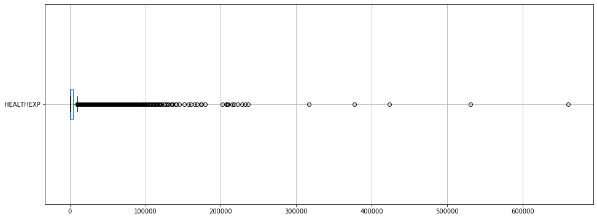

```python
# Check boxplot of target variable
plt.figure(figsize = (16, 6))
data[["HEALTHEXP"]].boxplot(vert = False)
plt.show()
```

```python
# Target variable has a long tail, hence logarithmic transformation of it.
# I use log with base 3 because it is near to e and natural logarithm is
# good but it could be difficult to interpret the results.
data["HEALTHEXP"] = transform_target_log3(data, "HEALTHEXP")
```

```python
# Check descriptive statistics of target variable after logarithmic transformation
data["HEALTHEXP"].describe()
```

```
count    18350.000000
mean         5.715444
std          2.756038
min          0.000000
25%          4.813588
50%          6.318143
75%          7.598196
max         12.197135
Name: HEALTHEXP, dtype: float64
```

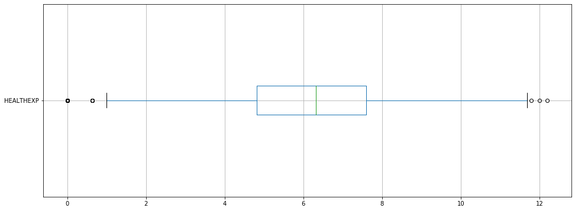

```python
# Check boxplot of target variable after logarithmic transformation
plt.figure(figsize = (16, 6))
data[["HEALTHEXP"]].boxplot(vert = False)
plt.show()
```

### 1) For the selected data set, train at least one tree-based ensemble model (random forest, gbm, catboost or any other boosting)

```python
# Prepare data
X = data.drop(columns = "HEALTHEXP")
y = data["HEALTHEXP"]

not_cat_cols_list = ["POVCAT15", "RTHLTH31", "MNHLTH31"]
categorical_features = get_categorical_features(X, not_cat_cols_list)
numerical_features= [f for f in X.columns if f not in categorical_features]

for f in categorical_features:
    X[f] = X[f].astype("str")

X_train, X_test, y_train, y_test = train_test_split(X, y, test_size = 0.33, random_state = 123)

X_train = X_train.reset_index(drop = True)
X_test = X_test.reset_index(drop = True)
y_train = y_train.reset_index(drop = True)
y_test = y_test.reset_index(drop = True)
```

```python
# Prepare model
categorical_transformer = Pipeline(
    steps = [
        ("onehot", OneHotEncoder(handle_unknown = "ignore"))
    ]
)

numerical_transformer = Pipeline(
    steps = [
        ("scaler", StandardScaler())
    ]
)

preprocessor = ColumnTransformer(
    transformers = [
        ("cat", categorical_transformer, categorical_features),
        ("num", numerical_transformer, numerical_features)
    ]
)

regressor = GradientBoostingRegressor(n_estimators = 76,
                                    max_depth = 5,
                                    min_samples_split = 2,
                                    min_samples_leaf = 5,
                                    random_state = 123)

reg = Pipeline(steps = [("preprocessor", preprocessor),
                      ("regressor", regressor)])


# Fit model
reg.fit(X_train, y_train)


# Check results
y_pred_train = reg.predict(X_train)
y_pred_test = reg.predict(X_test)

print_model_results(y_train, y_pred_train, y_test, y_pred_test)
```

```
Training:
RMSE:  2.036189044346683  | MAE:  1.5057966529875142  | R^2:  0.4576928489558483

Test:
RMSE:  2.1693560193082426  | MAE:  1.607849503417818  | R^2:  0.3719522211603923
```

### 2) For selected variables from the model (1) calculate Partial Dependence Profiles and Accumulated Local Dependence

```python
exp = dx.Explainer(reg, X_train, y_train)
```

```
Preparation of a new explainer is initiated

  -> label             : not specified, model's class taken instead!
  -> data              : 12294 rows 43 cols
  -> target variable   : Argument 'y' was a pandas.Series. Converted to a numpy.ndarray.
  -> target variable   : 12294 values
  -> predict function  : <function yhat_default at 0x0000027545B025E8> will be used
  -> predicted values  : min = -0.28766198807545573, mean = 5.704021670935211, max = 9.900700205189109
  -> residual function : difference between y and yhat
  -> residuals         : min = -7.916082503878272, mean = 2.1326685333941514e-16, max = 6.200730644797441
  -> model_info        : package sklearn

A new explainer has been created!
```

```python
plot_pdp_ale(exp, "numerical", ["AGE31X", "POVCAT15", "RTHLTH31", "MNHLTH31"])
```

```
The Panel class is removed from pandas. Accessing it from the top-level namespace will also be removed in the next version
```

[interactive chart not shown]

```python
plot_pdp_ale(exp, "categorical", ["GENDER", "INSCOV15", "CANCERDX", "HIBPDX"])
```

```
The Panel class is removed from pandas. Accessing it from the top-level namespace will also be removed in the next version
```

[interactive chart not shown]

### 3) Train a second model with a different structure (neural nets, linear, other boosting) and find a variable that has different behaviour between models

```python
# Prepare model
reg_lr = LinearRegression()

# Fit model
reg_lr.fit(X_train, y_train)

# Check results
y_pred_train = reg_lr.predict(X_train)
y_pred_test = reg_lr.predict(X_test)

print_model_results(y_train, y_pred_train, y_test, y_pred_test)
```

```
Training:
RMSE:  2.2896759163071234  | MAE:  1.731354047658843  | R^2:  0.3142636513938686

Test:
RMSE:  2.26760446782414  | MAE:  1.7118595279746591  | R^2:  0.31377643192880544
```

```python
exp_lr = dx.Explainer(reg_lr, X_train, y_train)
```

```
Preparation of a new explainer is initiated

  -> label             : not specified, model's class taken instead!
  -> data              : 12294 rows 43 cols
  -> target variable   : Argument 'y' was a pandas.Series. Converted to a numpy.ndarray.
  -> target variable   : 12294 values
  -> predict function  : <function yhat_default at 0x0000027545B025E8> will be used
  -> predicted values  : min = 1.0039576037431273, mean = 5.704021670935212, max = 11.195940770635348
  -> residual function : difference between y and yhat
  -> residuals         : min = -9.162183356883125, mean = -1.3506900711496291e-15, max = 6.455848791373203
  -> model_info        : package sklearn

A new explainer has been created!
```

```python
plot_pdp_ale(exp_lr, "numerical", ["AGE31X", "POVCAT15", "RTHLTH31", "MNHLTH31"])
```

```
The Panel class is removed from pandas. Accessing it from the top-level namespace will also be removed in the next version
```

[interactive chart not shown]

```python
plot_pdp_ale(exp_lr, "categorical", ["GENDER", "INSCOV15", "CANCERDX", "HIBPDX"])
```

```
The Panel class is removed from pandas. Accessing it from the top-level namespace will also be removed in the next version
```

[interactive chart not shown]